# Python Open Education Resource: Analogous R “Solution”

## (2) Create the PTSD Outcome Variable

The included reference for the PTSD data included in our research data set includes the following description to be used for diagnosis of PTSD:

> *“A provisional PTSD diagnosis can be made by treating each item rated as 2 =”Moderately" or higher as a symptom endorsed, then following the DSM-5 diagnostic rule which requires at least: 1 B item (questions 1-5), 1 C item (questions 6-7), 2 D items (questions 8-14), 2 E items (questions 15-20)."*

So for our 20 PTSD questions, for a patient to be meet our diagnostic criteria for PTSD, they must endorse a symptom (that is report a score of 2 or greater)

To use these criteria, we could set conditional arguments in a long if statement, but this would tediously require us to work through all 20 PTSD questions and carefully set up our conditionals:

```r
cohort <- cohort %>% rowwise() %>% # rowwise lets's R know the next operations (specifically `min` and `max`) within the mutate function are completed for each row (not the columns as a whole)
  mutate(PTSD_6mo =
           case_when(
             min(
               max(PTSD_Q1_6mo, PTSD_Q1_6mo, PTSD_Q2_6mo, PTSD_Q3_6mo, PTSD_Q4_6mo, PTSD_Q5_6mo),
               max(PTSD_Q6_6mo, PTSD_Q7_6mo),
               max(PTSD_Q8_6mo, PTSD_Q9_6mo, PTSD_Q10_6mo, PTSD_Q11_6mo, PTSD_Q12_6mo, PTSD_Q13_6mo, PTSD_Q14_6mo),
               max(PTSD_Q15_6mo, PTSD_Q16_6mo, PTSD_Q17_6mo, PTSD_Q18_6mo, PTSD_Q19_6mo, PTSD_Q20_6mo)
               )>=2 ~ 1,
             TRUE ~ 0
             )
         ) %>% ungroup() # "undoing" the `rowwise()` option we specified above, otherwise that attribute is saved, changing the object's class (see below)

cohort %>% count(PTSD_6mo) %>%  knitr::kable()
```

| PTSD_6mo | n |
| --- | --- |
| 0 | 258 |
| 1 | 143 |

```r
# Uncomment the below lines and examine the different object types
# cohort %>% class()
# cohort %>% rowwise() %>% class()
# cohort %>% rowwise() %>% ungroup() %>% class()
```

## (3) Create our suicidal related behavior (SRB) variable

As mentioned in the student assessment prompt, we can use the available PHQ-9 variable (related to Question 9 of the questionnaire) to categorize presence of SRB. Individuals who report a symptom (>=1) will be categorized as “present” and otherwise “absent” for our SRB outcome variable

```r
cohort <- cohort %>% mutate(SRB_6mo =
                              case_when(
                                PHQ_Q9_6mo>=1 ~ 1,
                                TRUE ~ 0
                              )
                            )

cohort %>% count(SRB_6mo) %>% knitr::kable()
```

| SRB_6mo | n |
| --- | --- |
| 0 | 238 |
| 1 | 163 |

```r
cohort %>% group_by(PTSD_6mo, SRB_6mo) %>% count() %>% knitr::kable()
```

| PTSD_6mo | SRB_6mo | n |
| --- | --- | --- |
| 0 | 0 | 174 |
| 0 | 1 | 84 |
| 1 | 0 | 64 |
| 1 | 1 | 79 |

## (4) Exploratory Data Analysis and Covariate Cleaning

We can reference our data dictionary to find our available covariates include age, time since earliest PTSD diagnosis, presence of alcohol abuse, a measure of anxiety (using the Beck Anxiety Inventory), a nominal-categorical value for income, a continuous self-reported assessment of social support, and lastly an indicator of the PTSD treatment medication prescribed over the study duration.

We could also examine the columns in our data frame to see what elements are present and the pecific names of the column containing this information:

```r
cohort %>% colnames() %>% as.data.frame() %>% knitr::kable()
```

| . |
| --- |
| UID |
| PTSD_Q1_6mo |
| PTSD_Q2_6mo |
| PTSD_Q3_6mo |
| PTSD_Q4_6mo |
| PTSD_Q5_6mo |
| PTSD_Q6_6mo |
| PTSD_Q7_6mo |
| PTSD_Q8_6mo |
| PTSD_Q9_6mo |
| PTSD_Q10_6mo |
| PTSD_Q11_6mo |
| PTSD_Q12_6mo |
| PTSD_Q13_6mo |
| PTSD_Q14_6mo |
| PTSD_Q15_6mo |
| PTSD_Q16_6mo |
| PTSD_Q17_6mo |
| PTSD_Q18_6mo |
| PTSD_Q19_6mo |
| PTSD_Q20_6mo |
| PHQ_Q9_6mo |
| Age |
| TimeFirstDiagnosis_Months |
| AlcAbuse |
| BeckAnxiety_BL |
| IncomeCat |
| SocialSupport |
| PTSD_Rx |
| PTSD_6mo |
| SRB_6mo |

```r
cohort %>% colnames %>% .[!stringr::str_detect(., "PTSD")] %>% as.data.frame() %>% knitr::kable()
```

| . |
| --- |
| UID |
| PHQ_Q9_6mo |
| Age |
| TimeFirstDiagnosis_Months |
| AlcAbuse |
| BeckAnxiety_BL |
| IncomeCat |
| SocialSupport |
| SRB_6mo |

### Continuous Variables

#### Age

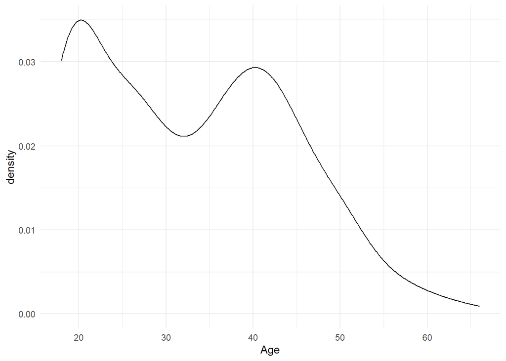

```r
library(ggplot2)


# Density Plot
cohort %>% ggplot(aes(x=Age)) +
  geom_density() +
  theme_minimal()
```

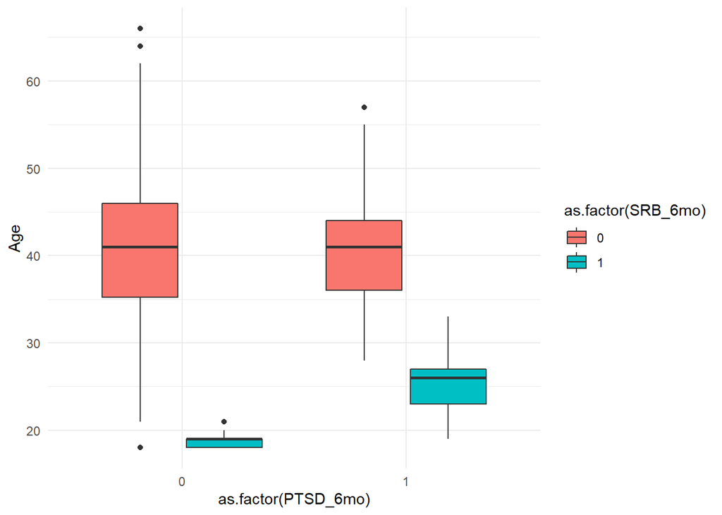

```r
# A lazy way of including all four categories
cohort %>% ggplot(aes(x=as.factor(PTSD_6mo), y=Age, fill=as.factor(SRB_6mo))) +
  geom_boxplot() +
  theme_minimal()
```

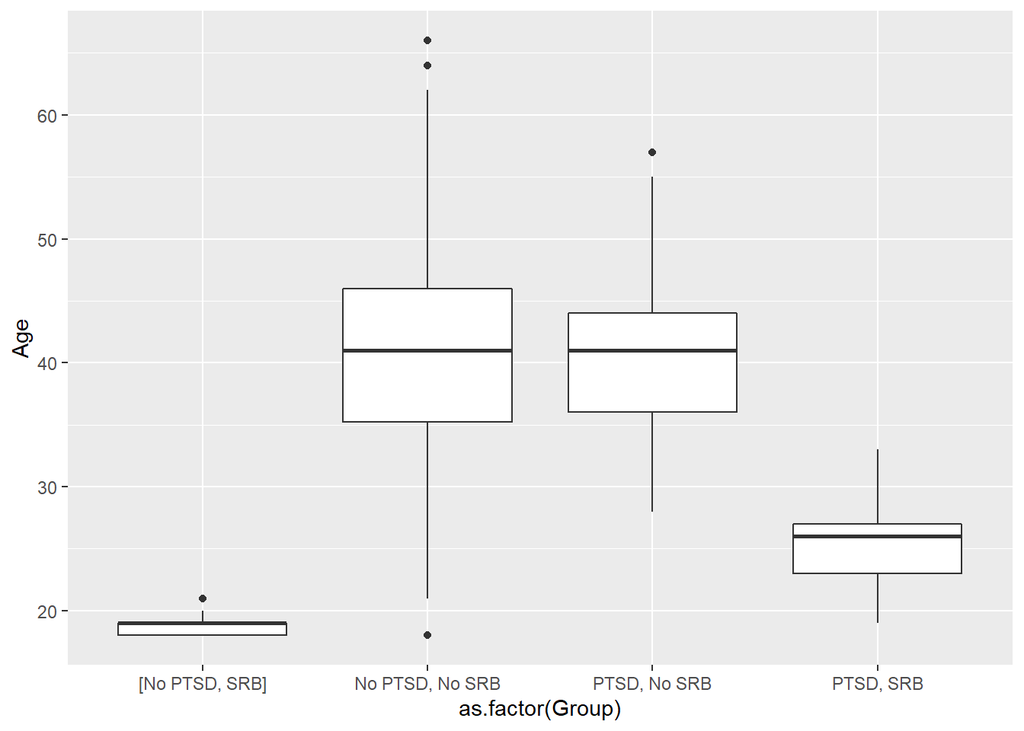

```r
# Creatinga new "interaction" variable of PTSD & SRB that more closely mirrors our two-grouped boxplot in matplotlib
cohort %>% mutate(Group =
                    case_when(
                      SRB_6mo==1 & PTSD_6mo==1 ~ "PTSD, SRB",
                      SRB_6mo==0 & PTSD_6mo==1 ~ "PTSD, No SRB",
                      SRB_6mo==1 & PTSD_6mo==0 ~ "[No PTSD, SRB]",
                      TRUE ~ "No PTSD, No SRB"
                    )
                  ) %>%
  ggplot(aes(x=as.factor(Group), y=Age)) +
  geom_boxplot()
```

#### Social Support

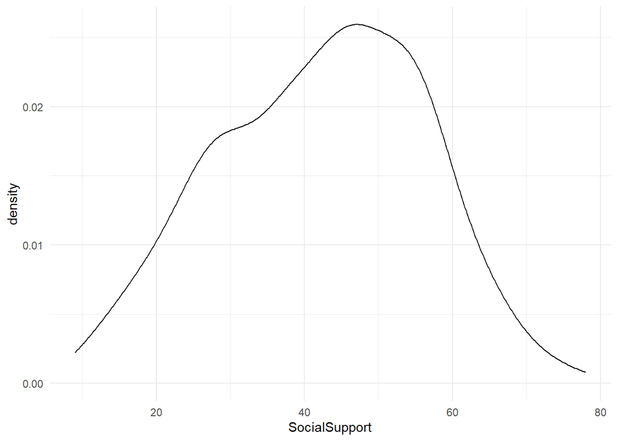

```r
# Density Plot
cohort %>% ggplot(aes(x=SocialSupport)) +
  geom_density() +
  theme_minimal()
```

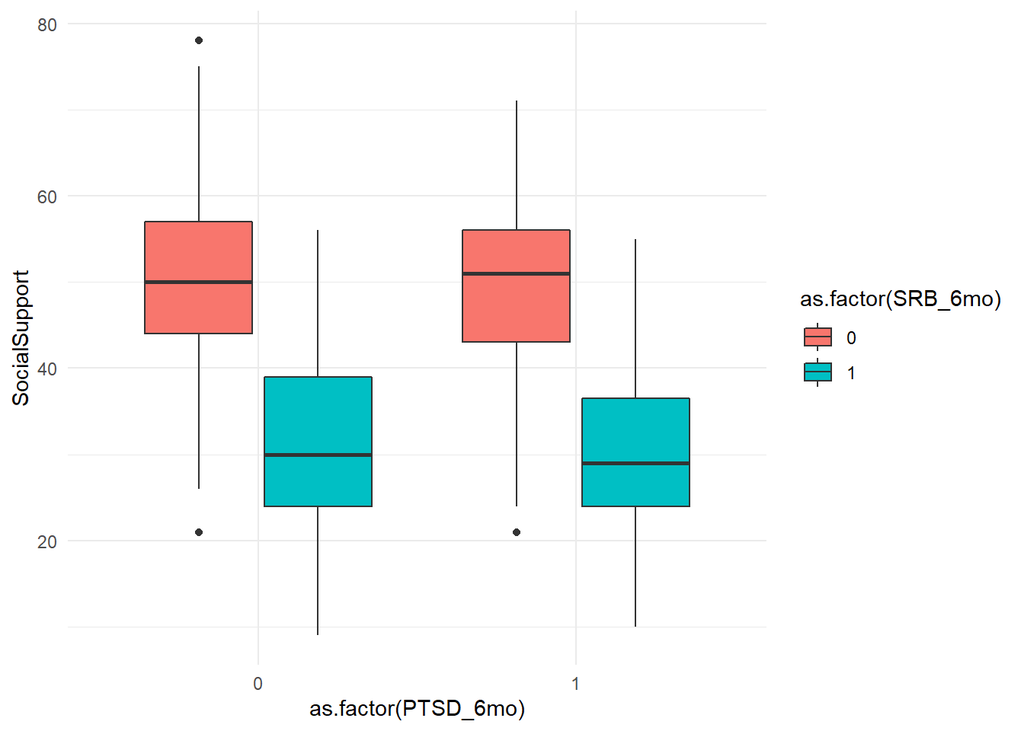

```r
# A lazy way of including all four categories
cohort %>% ggplot(aes(x=as.factor(PTSD_6mo), y=SocialSupport, fill=as.factor(SRB_6mo))) +
  geom_boxplot() +
  theme_minimal()
```

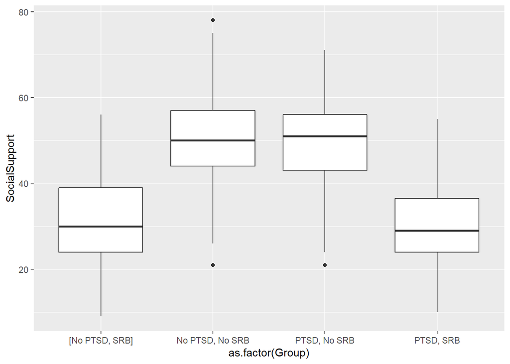

```r
# Creatinga new "interaction" variable of PTSD & SRB that more closely mirrors our two-grouped boxplot in matplotlib
cohort %>% mutate(Group =
                    case_when(
                      SRB_6mo==1 & PTSD_6mo==1 ~ "PTSD, SRB",
                      SRB_6mo==0 & PTSD_6mo==1 ~ "PTSD, No SRB",
                      SRB_6mo==1 & PTSD_6mo==0 ~ "[No PTSD, SRB]",
                      TRUE ~ "No PTSD, No SRB"
                    )
                  ) %>%
  ggplot(aes(x=as.factor(Group), y=SocialSupport)) +
  geom_boxplot()
```

#### Time to Diagnosis

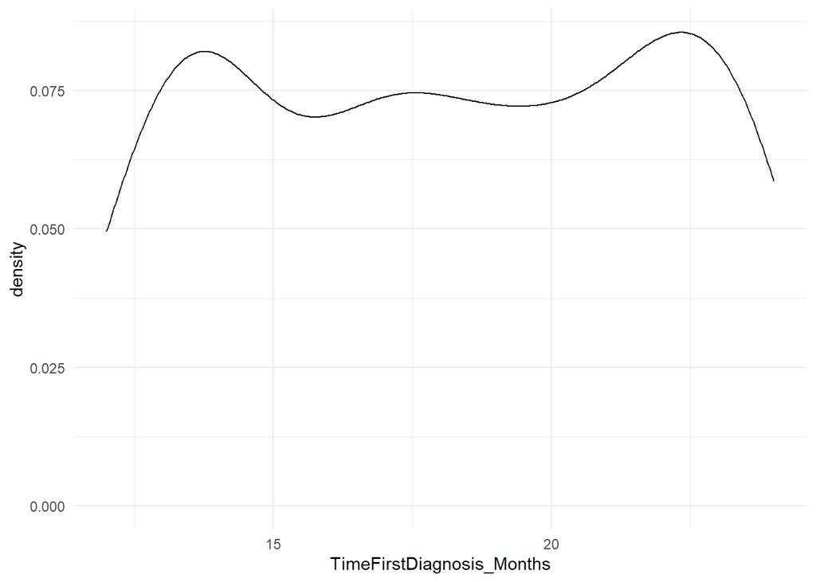

```r
# Density Plot
cohort %>% ggplot(aes(x=TimeFirstDiagnosis_Months)) +
  geom_density() +
  theme_minimal()
```

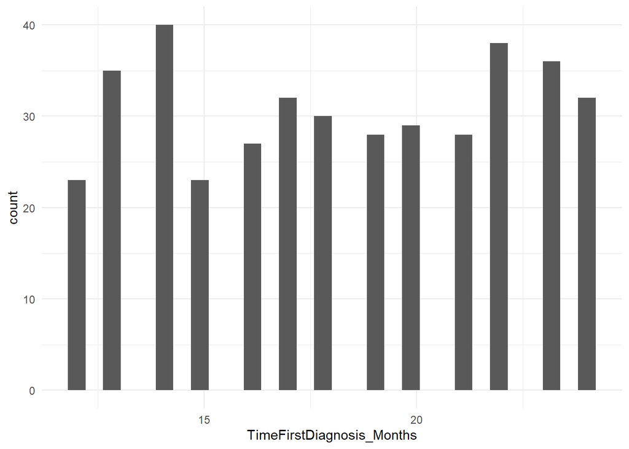

```r
cohort %>% ggplot(aes(x=TimeFirstDiagnosis_Months)) +
  geom_histogram() +
  theme_minimal()
```

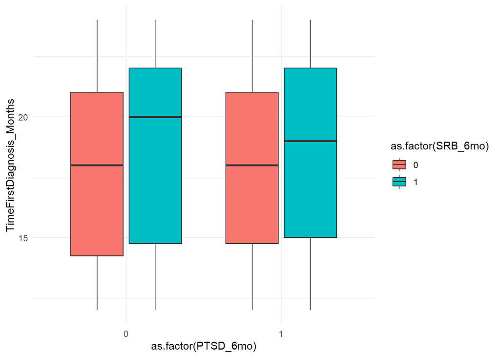

```r
# A lazy way of including all four categories
cohort %>% ggplot(aes(x=as.factor(PTSD_6mo), y=TimeFirstDiagnosis_Months, fill=as.factor(SRB_6mo))) +
  geom_boxplot() +
  theme_minimal()
```

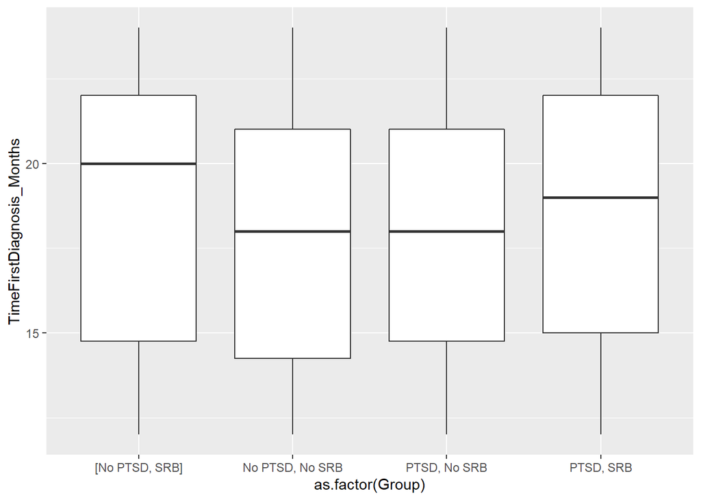

```r
# Creatinga new "interaction" variable of PTSD & SRB that more closely mirrors our two-grouped boxplot in matplotlib
cohort %>% mutate(Group =
                    case_when(
                      SRB_6mo==1 & PTSD_6mo==1 ~ "PTSD, SRB",
                      SRB_6mo==0 & PTSD_6mo==1 ~ "PTSD, No SRB",
                      SRB_6mo==1 & PTSD_6mo==0 ~ "[No PTSD, SRB]",
                      TRUE ~ "No PTSD, No SRB"
                    )
                  ) %>%
  ggplot(aes(x=as.factor(Group), y=TimeFirstDiagnosis_Months)) +
  geom_boxplot()
```

#### Beck Anxiety Interview

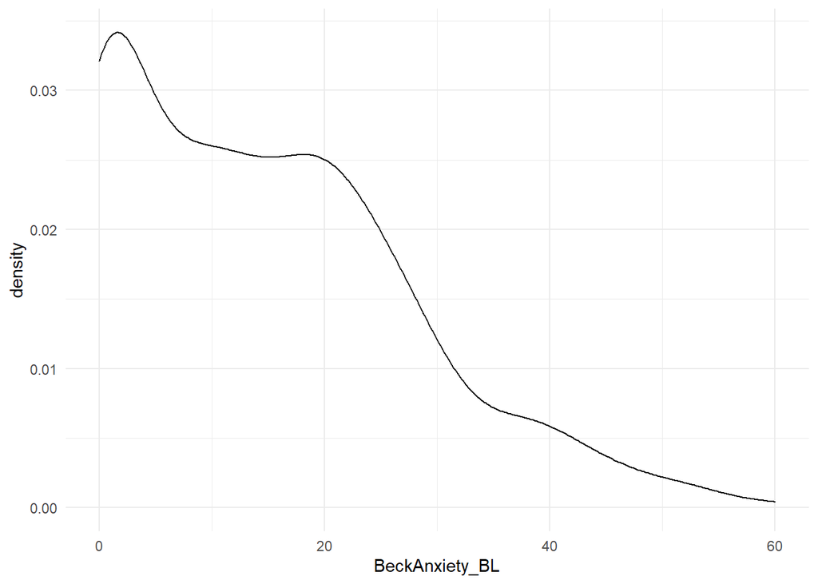

```r
# Density Plot
cohort %>% ggplot(aes(x=BeckAnxiety_BL)) +
  geom_density() +
  theme_minimal()
```

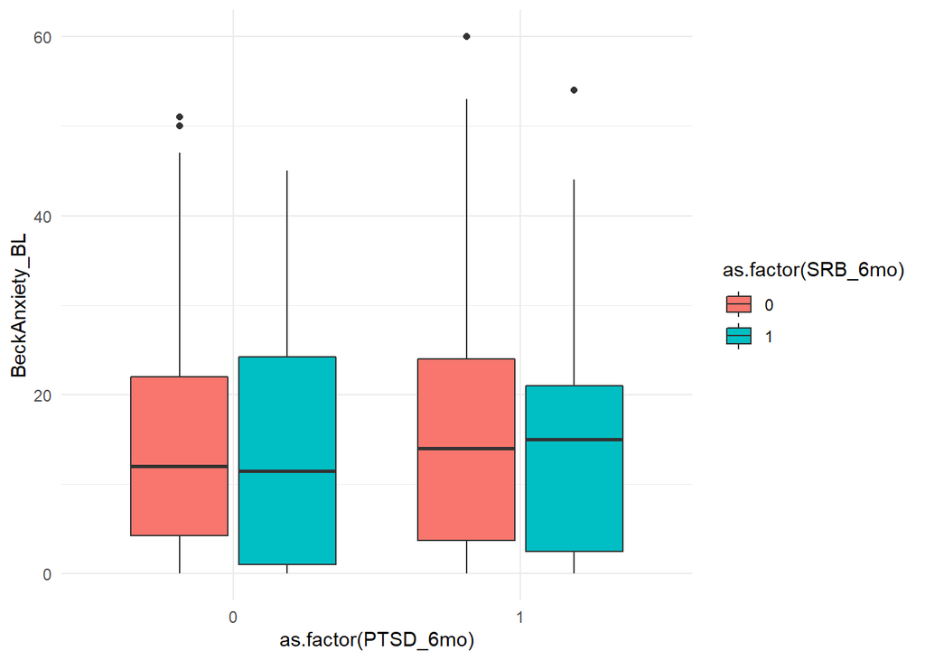

```r
# A lazy way of including all four categories
cohort %>% ggplot(aes(x=as.factor(PTSD_6mo), y=BeckAnxiety_BL, fill=as.factor(SRB_6mo))) +
  geom_boxplot() +
  theme_minimal()
```

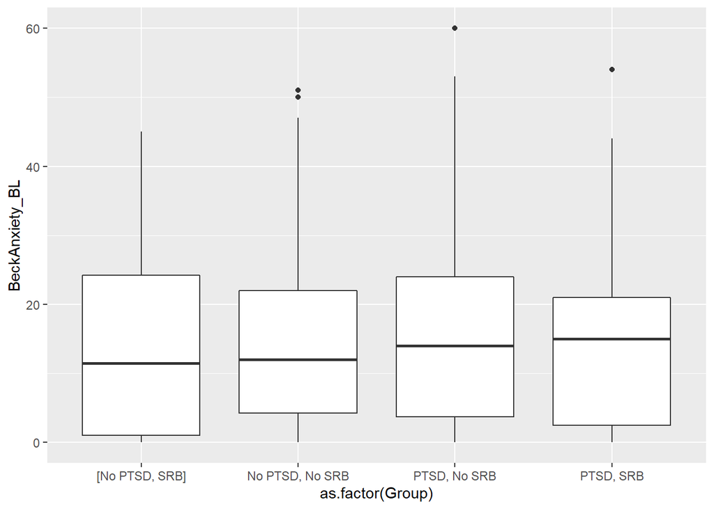

```r
# Creatinga new "interaction" variable of PTSD & SRB that more closely mirrors our two-grouped boxplot in matplotlib
cohort %>% mutate(Group =
                    case_when(
                      SRB_6mo==1 & PTSD_6mo==1 ~ "PTSD, SRB",
                      SRB_6mo==0 & PTSD_6mo==1 ~ "PTSD, No SRB",
                      SRB_6mo==1 & PTSD_6mo==0 ~ "[No PTSD, SRB]",
                      TRUE ~ "No PTSD, No SRB"
                    )
                  ) %>%
  ggplot(aes(x=as.factor(Group), y=BeckAnxiety_BL)) +
  geom_boxplot()
```

### Categorical Variables

For the categorical variables, we will examine the categories present, and in variables with more than 2 distinct categories, we will create dummy variables for all categories. For those with only 1 category (i.e. binary variables), we will simply leave the variable with its given “0/1” coding.

In Python, we utilized the `get_dummies()` function from `pandas`. In R, we do not necessarily have to convert our categorical variables into dummy variables. We can specify these variables are categorical using R’s `as.factor` function (as done above in some of the exploratory visualizations). As an example, we fit a quick regression model below without converting the `IncomeCat` variable (do not worry about the results or model, this is simply to demonstrate the utility of R’s `as.factor` in the model. We will review the modelling syntax and interpretation later):

```r
glm(SRB_6mo ~ Age + as.factor(IncomeCat),
    data=cohort,
    family="binomial") %>% summary()
```

```
##
## Call:
## glm(formula = SRB_6mo ~ Age + as.factor(IncomeCat), family = "binomial",
##     data = cohort)
##
## Deviance Residuals:
##     Min       1Q   Median       3Q      Max
## -2.8089  -0.1016  -0.0103   0.1795   2.2147
##
## Coefficients:
##                                   Estimate Std. Error z value Pr(>|z|)
## (Intercept)                       13.05645    1.55370   8.403  < 2e-16 ***
## Age                               -0.44684    0.05335  -8.376  < 2e-16 ***
## as.factor(IncomeCat)125%-200% FPL  0.25242    0.57847   0.436  0.66258
## as.factor(IncomeCat)200%-400% FPL -0.11131    0.62869  -0.177  0.85946
## as.factor(IncomeCat)400%+ FPL     -2.01386    0.67392  -2.988  0.00281 **
## ---
## Signif. codes:  0 '***' 0.001 '**' 0.01 '*' 0.05 '.' 0.1 ' ' 1
##
## (Dispersion parameter for binomial family taken to be 1)
##
##     Null deviance: 541.79  on 400  degrees of freedom
## Residual deviance: 135.46  on 396  degrees of freedom
## AIC: 145.46
##
## Number of Fisher Scoring iterations: 8
```

But to mirror the structure of the Python notebook, we can create the dummy variables using R’s `model.matrix` function, which computes a matrix of dummy variables for us

(*I will not save the results below, but present them as an analog to the python dummy variable creation code. I will utilize the `as.factor()` function within our model formulae*)

```r
cohort %>% model.matrix(~PTSD_Rx + IncomeCat, .) %>% cbind(cohort, .) %>% head() %>% knitr::kable()
```

| UID | PTSD_Q1_6mo | PTSD_Q2_6mo | PTSD_Q3_6mo | PTSD_Q4_6mo | PTSD_Q5_6mo | PTSD_Q6_6mo | PTSD_Q7_6mo | PTSD_Q8_6mo | PTSD_Q9_6mo | PTSD_Q10_6mo | PTSD_Q11_6mo | PTSD_Q12_6mo | PTSD_Q13_6mo | PTSD_Q14_6mo | PTSD_Q15_6mo | PTSD_Q16_6mo | PTSD_Q17_6mo | PTSD_Q18_6mo | PTSD_Q19_6mo | PTSD_Q20_6mo | PHQ_Q9_6mo | Age | TimeFirstDiagnosis_Months | AlcAbuse | BeckAnxiety_BL | IncomeCat | SocialSupport | PTSD_Rx | PTSD_6mo | … |
| --- | --- | --- | --- | --- | --- | --- | --- | --- | --- | --- | --- | --- | --- | --- | --- | --- | --- | --- | --- | --- | --- | --- | --- | --- | --- | --- | --- | --- | --- | --- |
| U200 | 1 | 0 | 0 | 0 | 0 | 1 | 0 | 1 | 0 | 0 | 3 | 3 | 4 | 2 | 2 | 0 | 0 | 1 | 0 | 0 | 0 | 29 | 18 | 0 | 24 | <125% FPL | 49 | clonazepam | 0 | … |
| U398 | 0 | 1 | 2 | 2 | 0 | 1 | 0 | 3 | 0 | 0 | 1 | 0 | 2 | 1 | 1 | 1 | 2 | 0 | 0 | 2 | 0 | 45 | 17 | 1 | 0 | 400%+ FPL | 59 | clonazepam | 0 | … |
| Z812 | 2 | 1 | 1 | 2 | 0 | 1 | 1 | 0 | 0 | 1 | 4 | 2 | 0 | 1 | 0 | 1 | 0 | 1 | 0 | 4 | 0 | 39 | 18 | 0 | 21 | 125%-200% FPL | 47 | clonazepam | 0 | … |
| U221 | 0 | 0 | 0 | 0 | 1 | 1 | 2 | 1 | 3 | 3 | 0 | 4 | 0 | 2 | 3 | 1 | 0 | 0 | 3 | 0 | 0 | 54 | 24 | 0 | 0 | <125% FPL | 48 | sertraline | 0 | … |
| U338 | 2 | 1 | 0 | 1 | 1 | 0 | 0 | 0 | 0 | 2 | 1 | 1 | 2 | 0 | 1 | 2 | 0 | 0 | 1 | 0 | 2 | 20 | 16 | 1 | 2 | 200%-400% FPL | 19 | nefazodone | 0 | … |
| U851 | 3 | 1 | 4 | 0 | 3 | 1 | 0 | 4 | 3 | 1 | 1 | 0 | 2 | 3 | 0 | 2 | 0 | 4 | 1 | 0 | 0 | 37 | 18 | 0 | 27 | <125% FPL | 44 | clonazepam | 0 | … |

```r
# cbind() combines the supplied arguments

# You can uncomment the code below to examine the model.matrix() function
# cohort %>% model.matrix(~PTSD_Rx + IncomeCat, .) %>% as.data.frame()
# Try looking at a single variable
# cohort %>% model.matrix(~PTSD_Rx,  .) %>% as.data.frame()
```

```r
cohort %>% count(AlcAbuse) %>% knitr::kable()
```

| AlcAbuse | n |
| --- | --- |
| 0 | 234 |
| 1 | 167 |

```r
cohort %>% count(IncomeCat) %>% knitr::kable()
```

| IncomeCat | n |
| --- | --- |
| <125% FPL | 106 |
| 125%-200% FPL | 105 |
| 200%-400% FPL | 73 |
| 400%+ FPL | 117 |

```r
cohort %>% count(PTSD_Rx) %>% knitr::kable()
```

| PTSD_Rx | n |
| --- | --- |
|  | 64 |
| clonazepam | 67 |
| midazolam | 62 |
| nefazodone | 55 |
| paroxetine | 44 |
| phenelzine | 64 |
| sertraline | 45 |

## Model Fitting

The model fitting section in this use case’s student assessment prompt is intentionally vague. The code below will include semi-structured walkthroughs and result presentations. Some of the important things to assess to ensure your solution satisfactorally meets the requirements of the assessment are included below:

- Including only the meaningful predictor variables of interest:
  - Removing the PTSD and PHQ questionnaire variables
  - Removing the `IncomeCat` and `PTSD_Rx` variables in favor of the indicator variables you previously created
  - Removing outcome variables from irrelevant model (e.g. do not include concurrent PTSD diagnosis as a predictor of SRB)
- Specifically applying algorithms with the ability to assess feature importance (see table below)
- Understanding the need to fit *classification* models to predict our binary outcomes of SRB and PTSD
- Presenting performance metrics of each model such as AUC/concordance
- Implementing a training and test split of the data
- Evaluating the relationship between predictors of interest and each outcome using model-appropriate metrics (e.g. odds ratios and p-values in logistic regression, feature importance in random forest, etc.)

More advanced “solutions” may include: - Within a single train/test split, performing k-fold or leave-one-out cross-validation within the training data to identify relevant model parameters - Comparing performance of multiple models and identifying the “best-fitting” modelling algorithm - Rather than simply extracted the predicted class of each algorithm, examine the predicted probabilities (for models that calcualte these values)

**Models & Feature Importance Meaurses**  
*This table is an **extremely** brief summary of modelling algorithms covered in the current course structure and the ability to easily assess feature importance within each sklearn implementation.*

| Model | Feature Importance Measure |
| --- | --- |
| Logistic Regression | Beta coefficients & p-values |
| Random Forest | Feature importance |
| Lasso/Elastic Net Regression | Beta coefficients & p-values |

**Models with no covariate inference/feature importance assessments (or measurements not covered within current courses)**

| Model | Description |
| --- | --- |
| Gaussian Naive Bayes | [Permutation Importance](https://stackoverflow.com/questions/62933365/how-to-get-the-feature-importance-in-gaussian-naive-bayes) |
| SVM | [Feature importance assessable only when using `linear` kernel](https://stackoverflow.com/questions/41592661/determining-the-most-contributing-features-for-svm-classifier-in-sklearn) |
| k-Nearest Neighbors | No implementation to assess feature importance |

```r
ptsd %>% filter(row_number()<=10) %>%  select(starts_with("PTSD"))

# for i in range(0, cohort.shape[0]):
#     if min(max(cohort.iloc[i, 1:6]), max(cohort.iloc[i, 6:8]),
#            max(cohort.iloc[i, 8:15]), max(cohort.iloc[i, 15:21]))>=2:
#         cohort.loc[i, 'PTSD_6mo'] = 1
#     else:
#         cohort.loc[i, 'PTSD_6mo'] = 0

logreg_obj <- glm(PTSD_6mo ~ Age + TimeFirstDiagnosis_Months + AlcAbuse + BeckAnxiety_BL + SocialSupport + as.factor(IncomeCat) +
                    as.factor(PTSD_Rx),
                  data=ptsd,
                  family="binomial")
```

[output not shown]